# Adding a subtitle to a ggplot2 plot

Martin Monkman

March 13, 2016

*This is an update to my series of blog posts, most recently [2015-01-06](http://bayesball.blogspot.com/2015/01/run-scoring-trends-using-shiny-to.html), visualizing run scoring trends in Major League Baseball.*

Earlier today I saw a tweet about some code to put a subtitle in a `ggplot2` plot. How do I get some of that, I asked myself? It turned out to be very simple, thanks to the work of Bob Rudis, shared in his [blog post “Subtitles in ggplot2”](http://rud.is/b/2016/03/12/ggplot2%E3%81%A7%E5%AD%97%E5%B9%95-subtitles-in-ggplot2/), and [cross-posted at R-bloggers.com](http://www.r-bloggers.com/ggplot2%E3%81%A7%E5%AD%97%E5%B9%95-subtitles-in-ggplot2/).

In order to replicate his work, I went back to some of my own code, drawing on the `Lahman` database package. The code summarizes the data, and creates a plot showing the annual average number of runs scored by each team in every season from 1901 through 2014, and adds a trend line using the loess smoothing method.

```r
# load the package into R, and open the data table 'Teams' into the
# workspace
library(Lahman)
data(Teams)
#
# package load
library(dplyr)
library(ggplot2)
#

# CREATE SUMMARY TABLE
# ====================
#

# create a new dataframe that
# - filters from 1901 [the establishment of the American League] to the most recent year,
# - filters out the Federal League
# - summarizes the total number of runs scored, runs allowed, and games played
# - calculates the league runs and runs allowed per game

MLB_RPG <- Teams %>%
  filter(yearID > 1900, lgID != "FL") %>%
  group_by(yearID) %>%
  summarise(R=sum(R), RA=sum(RA), G=sum(G)) %>%
  mutate(leagueRPG=R/G, leagueRAPG=RA/G)
```

Plot the MLB runs per game trend:

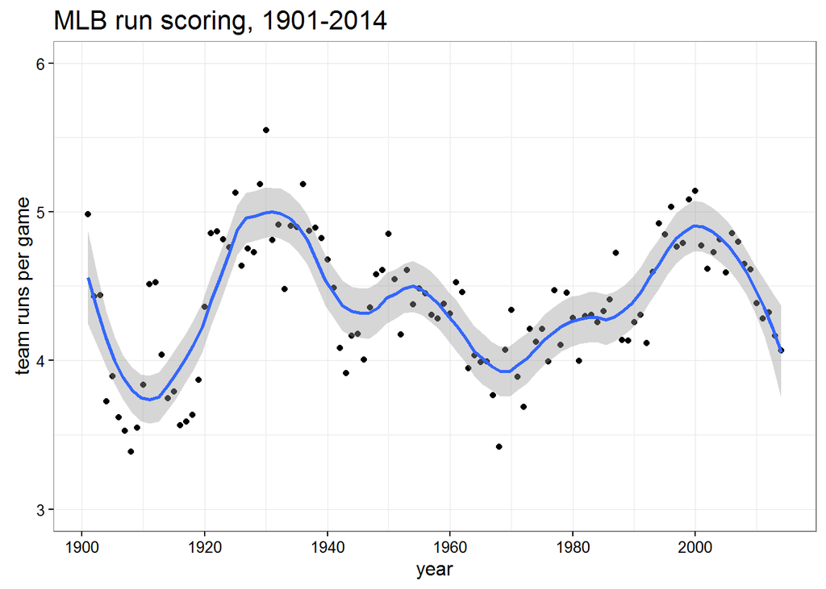

```r
MLBRPGplot <- ggplot(MLB_RPG, aes(x=yearID, y=leagueRPG)) +
  geom_point() +
  theme_bw() +
  theme(panel.grid.minor = element_line(colour="gray95")) +
  scale_x_continuous(breaks = seq(1900, 2015, by = 20)) +
  scale_y_continuous(limits = c(3, 6), breaks = seq(3, 6, by = 1)) +
  xlab("year") +
  ylab("team runs per game") +
  geom_smooth(span = 0.25) +
  ggtitle("MLB run scoring, 1901-2014") +
  theme(plot.title = element_text(hjust=0, size=16))


MLBRPGplot
```

#### Adding a subtitle: the function

So now we have a nice looking dot plot showing the average number of runs scored per game for the years 1901-2014.

But a popular feature of charts—particularly in magazines—is a subtitle that has a summary of what the chart shows and/or what the author wants to emphasize.

How can we add a subtitle to our chart that does that?

Bob Rudis has created a function that quickly and easily allows us to add a subtitle. The following code is taken from his [blog post “Subtitles in ggplot2” of 2016-03-12](http://rud.is/b/2016/03/12/ggplot2%E3%81%A7%E5%AD%97%E5%B9%95-subtitles-in-ggplot2/).

The code for this function relies on two additional packages, `grid` and `gtable`. Other than the package loads, this is a straight copy/paste from Bob’s blog post.

```r
library(grid)
library(gtable)

ggplot_with_subtitle <- function(gg,
                                 label="",
                                 fontfamily=NULL,
                                 fontsize=10,
                                 hjust=0, vjust=0,
                                 bottom_margin=5.5,
                                 newpage=is.null(vp),
                                 vp=NULL,
                                 ...) {

  if (is.null(fontfamily)) {
    gpr <- gpar(fontsize=fontsize, ...)
  } else {
    gpr <- gpar(fontfamily=fontfamily, fontsize=fontsize, ...)
  }

  subtitle <- textGrob(label, x=unit(hjust, "npc"), y=unit(hjust, "npc"),
                       hjust=hjust, vjust=vjust,
                       gp=gpr)

  data <- ggplot_build(gg)

  gt <- ggplot_gtable(data)
  gt <- gtable_add_rows(gt, grobHeight(subtitle), 2)
  gt <- gtable_add_grob(gt, subtitle, 3, 4, 3, 4, 8, "off", "subtitle")
  gt <- gtable_add_rows(gt, grid::unit(bottom_margin, "pt"), 3)

  if (newpage) grid.newpage()

  if (is.null(vp)) {
    grid.draw(gt)
  } else {
    if (is.character(vp)) seekViewport(vp) else pushViewport(vp)
    grid.draw(gt)
    upViewport()
  }

  invisible(data)

}
```

#### Adding a subtitle

Now we’ve got the function loaded into our R workspace, the steps are easy:

- Rename the active plot object `gg` (simply because that’s what Bob’s code uses)
- Define the text that we want to be in the subtitle
- Call the function

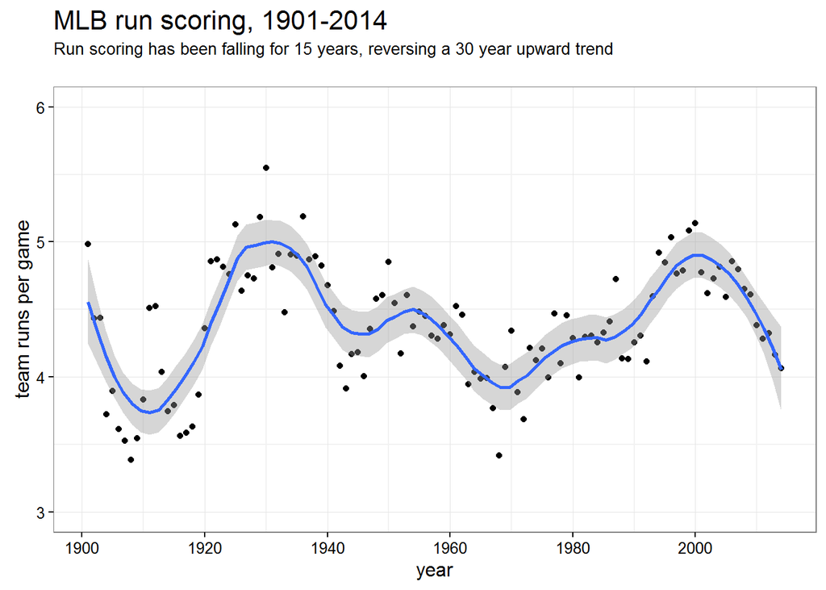

```r
# set the name of the current plot object to "gg"
gg <- MLBRPGplot

# define the subtitle text
subtitle <-
  "Run scoring has been falling for 15 years, reversing a 30 year upward trend"

ggplot_with_subtitle(gg, subtitle,
                     bottom_margin=20, lineheight=0.9)
```

Wasn’t that easy? Thanks, Bob!

And it’s going to get easier—in the few days since his blog post, Bob Rudis has taken this into the `ggplot2` development environment, working on the code necessary to add this as a simple extension to the package’s already extensive functionality. It’s early days, but it’s looking great. (See [`ggplot2` Pull request #1582](https://github.com/hadley/ggplot2/pull/1582).) Thanks again, Bob!

And thanks also to the rest of the `ggplot2` developers, for making those of us who use the package create good-looking and effective data visualization.

-30-